# Segmentación de clientes corporativos

### 2.28. Transacciones de salida por el canal 5

```r
resumir_datos(datos_segmentados, sal_tx_canal5, moneda = FALSE)
```

| grupo | Media | Mínimo | Q1 | Mediana | Q3 | Máximo | ceros |
| --- | --- | --- | --- | --- | --- | --- | --- |
| 1 | 0.64 | 0 | 0 | 0 | 0.00 | 17.17 | 80.11% |
| 2 | 8.28 | 0 | 0 | 2 | 7.25 | 516.50 | 33.74% |

Los resultados del canal 5 nos muestran lo mismo que se ha visto hasta el momento, donde el grupo 2 maneja una cantidad mayor de transacciones y presenta una actividad mayor a la evidenciada para el grupo 1.

**Click para ver el gráfico de caja**

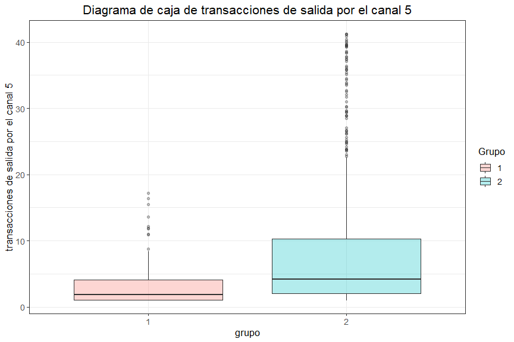

```r
crear_boxplot(datos_segmentados, sal_tx_canal5, extremos = FALSE, ceros = FALSE,
              etiqueta = "transacciones de salida por el canal 5")
```

**Nota:** Este gráfico se realiza con el 95% inferior de los datos diferentes de cero con la intención de ilustrar como se comportan la mayor parte de los clientes a través de cada grupo.

### 2.29. Transacciones de salida por el canal 8

```r
resumir_datos(datos_segmentados, sal_tx_canal8, moneda = FALSE)
```

| grupo | Media | Mínimo | Q1 | Mediana | Q3 | Máximo | ceros |
| --- | --- | --- | --- | --- | --- | --- | --- |
| 1 | 0.04 | 0 | 0 | 0 | 0 | 17 | 98.48% |
| 2 | 3.70 | 0 | 0 | 0 | 0 | 4,586 | 80.7% |

El canal 8 nos muestra una inactividad casi total por parte de los clientes del grupo 1, los cuales además manejan valores menores a los del grupo 2.

**Click para ver el gráfico de caja**

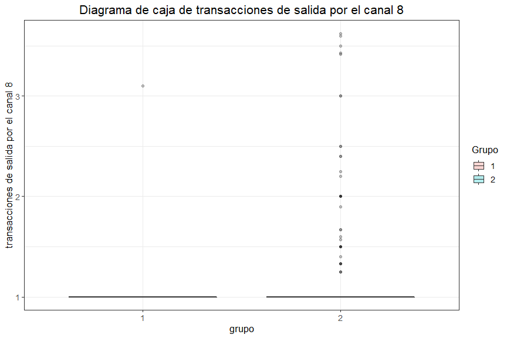

```r
crear_boxplot(datos_segmentados, sal_tx_canal8, extremos = FALSE, ceros = FALSE,
              etiqueta = "transacciones de salida por el canal 8")
```

**Nota:** Este gráfico se realiza con el 95% inferior de los datos diferentes de cero con la intención de ilustrar como se comportan la mayor parte de los clientes a través de cada grupo.

### 2.30. Transacciones de salida por el canal otros

```r
resumir_datos(datos_segmentados, sal_tx_otros, moneda = FALSE)
```

| grupo | Media | Mínimo | Q1 | Mediana | Q3 | Máximo | ceros |
| --- | --- | --- | --- | --- | --- | --- | --- |
| 1 | 0.24 | 0 | 0 | 0 | 0 | 39.25 | 98.48% |
| 2 | 1.24 | 0 | 0 | 0 | 0 | 579.21 | 94.94% |

Si bien ambos grupos presentan una inactividad importante a través de este canal, los resultados de la tabla nos permiten finalmente concluir que el grupo 2 se consolida como el más activo, con valores mas altos en cada uno de los canales tanto de entrada como de salida.

**Click para ver el gráfico de caja**

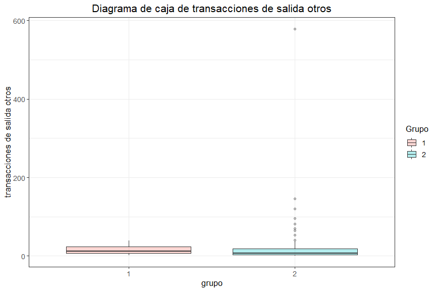

```r
crear_boxplot(datos_segmentados, sal_tx_otros, extremos = T, ceros = FALSE,
              etiqueta = "transacciones de salida otros")
```

El gráfico muestra una información diferente al resumen numérico, esto debido a que en su creación no se utilizaron los datos en cero, los cuales constituyen casi la totalidad de clientes del grupo 1, lo anterior se hace con la intención de ilustrar la diferencia entre los grupos.

### 2.31. Proporción de **$\frac{importaciones}{compras}$**

```r
resumir_datos(datos_segmentados, impo_cv, continuo = FALSE, moneda = FALSE)
```

| grupo | Media | Mínimo | Q1 | Mediana | Q3 | Máximo |
| --- | --- | --- | --- | --- | --- | --- |
| 1 | 1.72 | 1 | 1 | 1 | 2 | 5 |
| 2 | 2.21 | 1 | 1 | 2 | 3 | 5 |

La tabla nos indica que los clientes del grupo 2 tienden a realizar más importaciones que los del grupo 1, lo cual se evidencia principalmente en los valores de la mediana y la media.

```r
proporciones_categoricas(datos_segmentados, impo_cv)
```

| impo_cv | grupo 1 | grupo 2 |
| --- | --- | --- |
| 1 | 52.9% | 27.94% |
| 2 | 32.04% | 40.22% |
| 3 | 7.32% | 17.07% |
| 4 | 5.52% | 12.75% |
| 5 | 2.21% | 2.02% |

Por otro lado, la tabla de proporciones nos indica que los clientes asociados al grupo 1 están principalmente concentrados en los dos principales niveles, reflejando que se trata de empresas que realizan una baja o nula cantidad de importaciones respecto a sus compras totales. Por su parte los asociados al grupo 2 están concentrados del nivel 2 en adelante, indicando que se trata de empresas que realizan más importaciones que lo evidenciado para el primer grupo.

**Click para ver el gráfico de caja**

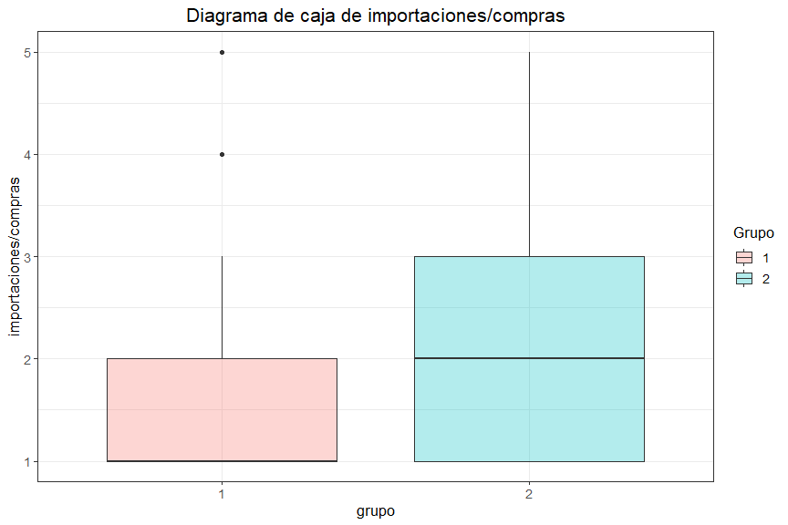

```r
crear_boxplot(datos_segmentados, impo_cv,
              etiqueta = "importaciones/compras")
```

### 2.32. Proporción de **$\frac{exportaciones}{ventas}$**

```r
resumir_datos(datos_segmentados, expo_vt, continuo = FALSE, moneda = FALSE)
```

| grupo | Media | Mínimo | Q1 | Mediana | Q3 | Máximo |
| --- | --- | --- | --- | --- | --- | --- |
| 1 | 1.52 | 1 | 1 | 1 | 2 | 3 |
| 2 | 1.82 | 1 | 1 | 2 | 2 | 3 |

La tabla de resumenes numéricos indica que los clientes asociados al grupo 2 tienden a exportar más productos que los del grupo 1, esto se puede apreciar principalmente en los valores de la mediana y la media.

```r
proporciones_categoricas(datos_segmentados, expo_vt)
```

| expo_vt | grupo 1 | grupo 2 |
| --- | --- | --- |
| 1 | 52.9% | 27.94% |
| 2 | 42.13% | 62.08% |
| 3 | 4.97% | 9.99% |

**Click para ver el gráfico de caja**

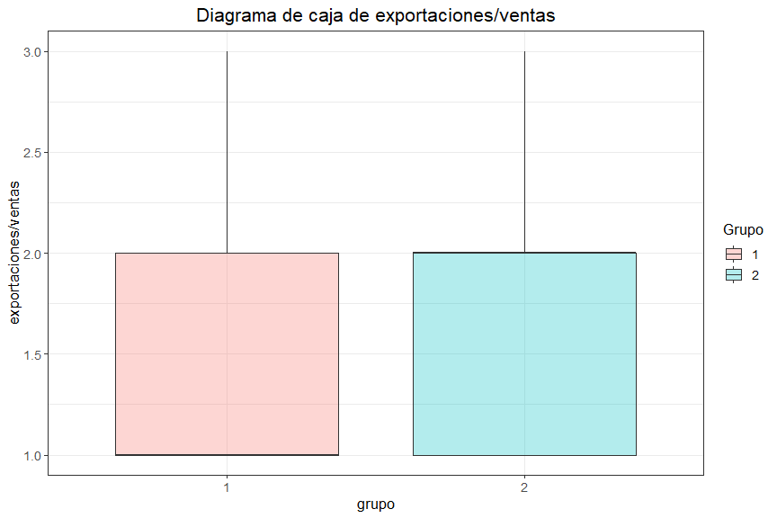

```r
crear_boxplot(datos_segmentados, expo_vt,
              etiqueta = "exportaciones/ventas")
```

### 2.33. Cuentas por pagar

```r
resumir_datos(datos_segmentados, cxp, continuo = FALSE, moneda = FALSE)
```

| grupo | Media | Mínimo | Q1 | Mediana | Q3 | Máximo |
| --- | --- | --- | --- | --- | --- | --- |
| 1 | 2.35 | 1 | 1 | 2 | 3 | 6 |
| 2 | 3.19 | 1 | 2 | 3 | 5 | 6 |

La tabla de resumenes numéricos indica que que los clientes asociados al grupo 2 poseen una mayor cantidad de cuentas por pagar, lo cual se aprecia en la superioridad que presentan en cada una de las medidas.

```r
proporciones_categoricas(datos_segmentados, cxp)
```

| cxp | grupo 1 | grupo 2 |
| --- | --- | --- |
| 1 | 34.67% | 15.72% |
| 2 | 36.05% | 31.31% |
| 3 | 11.74% | 18.42% |
| 4 | 4.83% | 8.37% |
| 5 | 3.04% | 5.33% |
| 6 | 9.67% | 20.85% |

La tabla de proporciones nos permite observar de una mejor manera lo mencionado anteriormente dado que para los dos primeros niveles se observa una clara superioridad del grupo 1, indicando que se constituye en gran medida por clientes que tienen una baja o moderadamente baja cantidad de cuentas por pagar, comportamiento que se invierte a partir del nivel 3, donde el grupo 2 empieza a dominar, indicando que posee una proporción mayor de empresas con gran cantidad de cuentas por pagar.

**Click para ver el gráfico de caja**

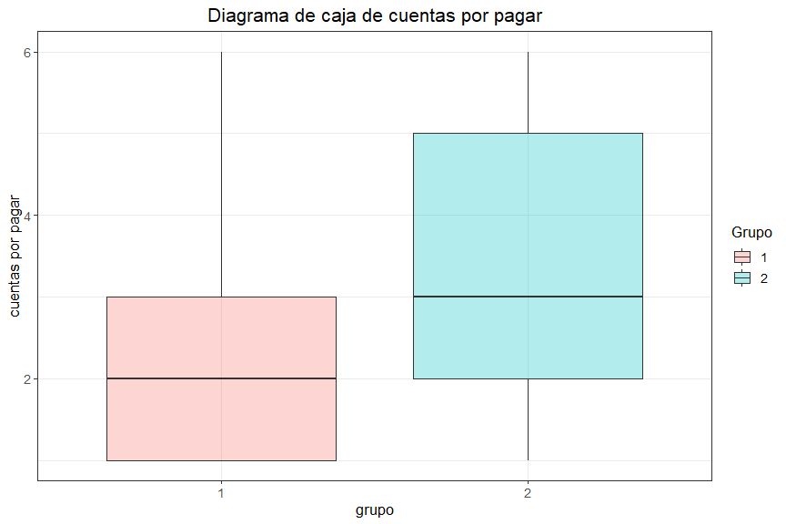

```r
crear_boxplot(datos_segmentados, cxp,
              etiqueta = "cuentas por pagar")
```

### 2.34. Cuentas por cobrar

```r
resumir_datos(datos_segmentados, cxc, continuo = FALSE, moneda = FALSE)
```

| grupo | Media | Mínimo | Q1 | Mediana | Q3 | Máximo |
| --- | --- | --- | --- | --- | --- | --- |
| 1 | 2.88 | 1 | 1 | 2 | 4 | 6 |
| 2 | 3.80 | 1 | 2 | 3 | 6 | 6 |

Las cuentas por cobrar evidencian un comportamiento similar a las cuentas por pagar, donde existe una clara dominación por parte del grupo 2 en cada una de las medidas, indicando que los clientes asociados a este poseen una cantidad superior de deudas a favor en comparación con el grupo 1.

```r
proporciones_categoricas(datos_segmentados, cxc)
```

| cxc | grupo 1 | grupo 2 |
| --- | --- | --- |
| 1 | 27.21% | 8.5% |
| 2 | 28.18% | 22.6% |
| 3 | 15.47% | 20.18% |
| 4 | 6.08% | 9.18% |
| 5 | 5.11% | 8.3% |
| 6 | 17.96% | 31.24% |

La tabla de proporciones muestra de una forma más clara el comportamiento previamente descrito, donde el grupo 1 domina principalmente en los dos primeros niveles, mientras que el segundo grupo domina principalmente a partir del tercer nivel, confirmando que este ultimo está constituido por clientes con más cuentas por cobrar.

**Click para ver el gráfico de caja**

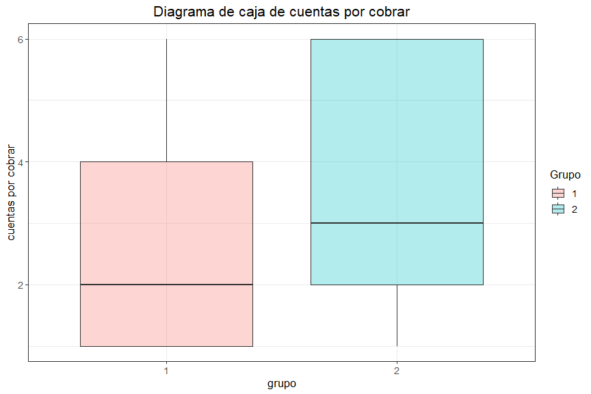

```r
crear_boxplot(datos_segmentados, cxc,
              etiqueta = "cuentas por cobrar")
```

### 2.35. Total de inventarios

```r
resumir_datos(datos_segmentados, totalinventory, continuo = FALSE, moneda = FALSE)
```

| grupo | Media | Mínimo | Q1 | Mediana | Q3 | Máximo |
| --- | --- | --- | --- | --- | --- | --- |
| 1 | 2.61 | 1 | 1 | 2 | 3 | 6 |
| 2 | 3.71 | 1 | 2 | 3 | 6 | 6 |

En el total de inventarios se evidencia nuevamente lo visto para las cuentas por pagar y por cobrar, donde el grupo 1 presenta valores mas bajos en todas las medidas, indicando que los clientes del grupo 2 poseen un total de inventarios superior.

```r
proporciones_categoricas(datos_segmentados, totalinventory)
```

| totalinventory | grupo 1 | grupo 2 |
| --- | --- | --- |
| 1 | 29.56% | 10.93% |
| 2 | 34.53% | 22% |
| 3 | 12.71% | 18.49% |
| 4 | 5.8% | 11.47% |
| 5 | 3.59% | 8.16% |
| 6 | 13.81% | 28.95% |

La tabla de proporciones confirma lo mencionado anteriormente, donde el grupo 1 domina principalmente en los dos primeros niveles, evidenciando que los cientes asociados a este poseen un bajo o medio bajo total de inventarios, mientras que los pertenecientes al grupo 2 se distribuyen en valores más altos.

**Click para ver el gráfico de caja**

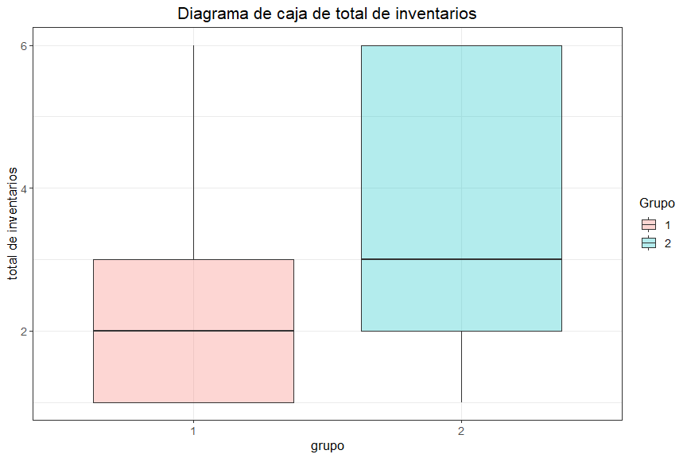

```r
crear_boxplot(datos_segmentados, totalinventory,
              etiqueta = "total de inventarios")
```

### 2.36. Pagos a personas jurídicas

```r
resumir_datos(datos_segmentados, pagos_pj, continuo = FALSE, moneda = FALSE)
```

| grupo | Media | Mínimo | Q1 | Mediana | Q3 | Máximo |
| --- | --- | --- | --- | --- | --- | --- |
| 1 | 0.64 | 0 | 0.44 | 0.67 | 0.89 | 1 |
| 2 | 0.50 | 0 | 0.30 | 0.47 | 0.69 | 1 |

En esta característica se invierte la tendencia vista hasta el momento, donde las empresas pertenecientes al grupo 1 presentan valores más elevados en todas las medidas de resumen, indicando que poseen una mayor proporción de pagos hechos a personas jurídicas que las pertenecientes al grupo 2.

**Click para ver el gráfico de caja**

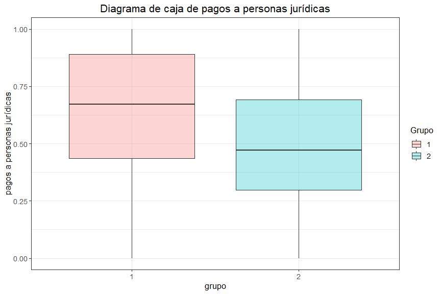

```r
crear_boxplot(datos_segmentados, pagos_pj,
              etiqueta = "pagos a personas jurídicas")
```

### 2.37. Pagos a personas naturales

```r
resumir_datos(datos_segmentados, pagos_pn, continuo = FALSE, moneda = FALSE)
```

| grupo | Media | Mínimo | Q1 | Mediana | Q3 | Máximo |
| --- | --- | --- | --- | --- | --- | --- |
| 1 | 0.34 | 0 | 0.1 | 0.31 | 0.54 | 1.00 |
| 2 | 0.50 | 0 | 0.3 | 0.53 | 0.70 | 0.99 |

Contrario al punto anterior, en las medidas de resumen se aprecia que los clientes del grupo 2 tiende a realizar una mayor proporción de pagos a personas naturales en comparación con los asociados al grupo 1.

**Click para ver el gráfico de caja**

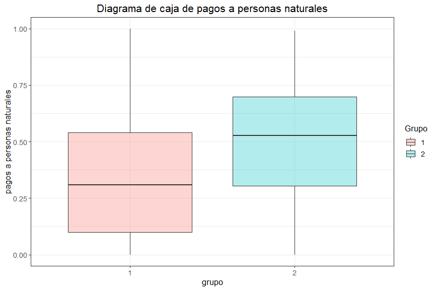

```r
crear_boxplot(datos_segmentados, pagos_pn,
              etiqueta = "pagos a personas naturales")
```

### 2.38. Tiene ventas físicas

```r
resumir_datos(datos_segmentados, tiene_ventas_fisicas, continuo = FALSE, moneda = FALSE)
```

| grupo | Media | Mínimo | Q1 | Mediana | Q3 | Máximo |
| --- | --- | --- | --- | --- | --- | --- |
| 1 | 0.19 | 0 | 0 | 0 | 0 | 1 |
| 2 | 0.62 | 0 | 0 | 1 | 1 | 1 |

Los resultados de las medidas de resumen nos permiten afirmar que el grupo 2 posee una mayor proporción de empresas que tienen ventas físicas, esto se aprecia principalmente en el valor de la media.

```r
proporciones_categoricas(datos_segmentados, tiene_ventas_fisicas)
```

| tiene_ventas_fisicas | grupo 1 | grupo 2 |
| --- | --- | --- |
| 0 | 81.22% | 37.52% |
| 1 | 18.78% | 62.48% |

La tabla de proporciones confirma de forma clara la información aportada por las medidas de resumen, donde el 81.22% de las empresas del grupo 1 no poseen ventas físicas, mientras que el 62.48% de las asociadas al grupo 2 si las poseen.

### 2.39. Tiene ventas electrónicas

```r
resumir_datos(datos_segmentados, tiene_ventas_electronicas, continuo = FALSE, moneda = FALSE)
```

| grupo | Media | Mínimo | Q1 | Mediana | Q3 | Máximo |
| --- | --- | --- | --- | --- | --- | --- |
| 1 | 0.01 | 0 | 0 | 0 | 0 | 1 |
| 2 | 0.07 | 0 | 0 | 0 | 0 | 1 |

Los resultados de esta característica no son muy alentadores para ningún grupo, sin embargo se resalta que el segundo continúa mostrando valores mas altos, donde cerca del 7% de las empresas asociadas poseen ventas electrónicas.

```r
proporciones_categoricas(datos_segmentados, tiene_ventas_electronicas)
```

| tiene_ventas_electronicas | grupo 1 | grupo 2 |
| --- | --- | --- |
| 0 | 99.31% | 92.78% |
| 1 | 0.69% | 7.22% |

El resultado de la tabla de proporciones solo confirma lo dicho previamente, el grupo 2 continúa manteniendo valores mas altos que los del grupo 1.

### 2.40. Recaudos provenientes de personas jurídicas

```r
resumir_datos(datos_segmentados, recaudos_pj, continuo = FALSE, moneda = FALSE)
```

| grupo | Media | Mínimo | Q1 | Mediana | Q3 | Máximo |
| --- | --- | --- | --- | --- | --- | --- |
| 1 | 0.00 | 0 | 0 | 0 | 0 | 0.5 |
| 2 | 0.04 | 0 | 0 | 0 | 0 | 1.0 |

Los valores de las medidas de resumen indican que los recaudos provenientes jurídicas no son muy usuales, sin embargo la tendencia evidenciada hasta el momento continúa estando presente, donde los clientes asociados al grupo 2 tienen los valores más altos.

**Click para ver el gráfico de caja**

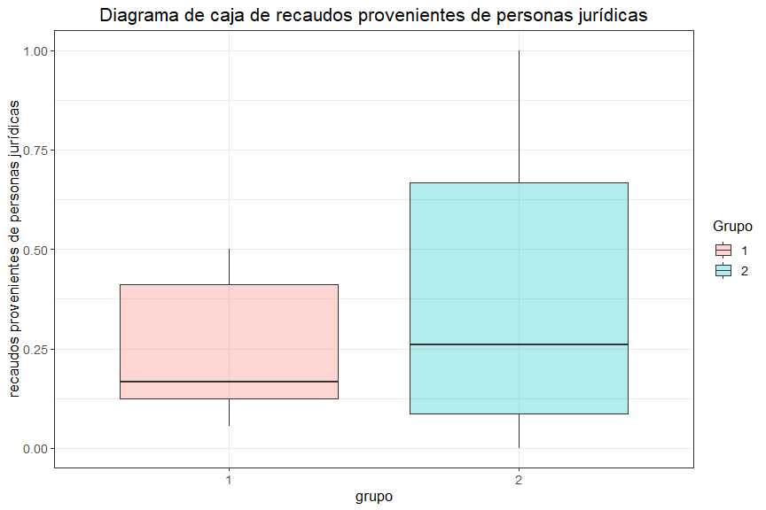

```r
crear_boxplot(datos_segmentados, recaudos_pj, ceros = FALSE,
              etiqueta = "recaudos provenientes de personas jurídicas")
```

### 2.41. Recaudos provenientes de personas naturales

```r
resumir_datos(datos_segmentados, recaudos_pn, continuo = FALSE, moneda = FALSE)
```

| grupo | Media | Mínimo | Q1 | Mediana | Q3 | Máximo |
| --- | --- | --- | --- | --- | --- | --- |
| 1 | 0.01 | 0 | 0 | 0 | 0 | 1 |
| 2 | 0.09 | 0 | 0 | 0 | 0 | 1 |

Similar al resultado anterior, los recaudos provenientes de personas naturales no parecen ser muy usuales, sin embargo, el grupo 2 continúa manteniendo los valores más altos, lo cual se evidencia principalmente en el valor de la media.

**Click para ver el gráfico de caja**

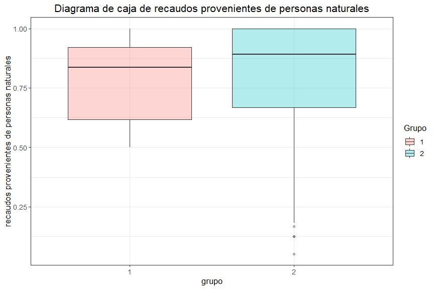

```r
crear_boxplot(datos_segmentados, recaudos_pn, ceros = FALSE,
              etiqueta = "recaudos provenientes de personas naturales")
```

### 2.42. Rotación de inventarios

```r
resumir_datos(datos_segmentados, rotacion_inventarios, continuo = FALSE, moneda = FALSE)
```

| grupo | Media | Mínimo | Q1 | Mediana | Q3 | Máximo |
| --- | --- | --- | --- | --- | --- | --- |
| 1 | 2.93 | 1 | 1 | 2 | 5 | 6 |
| 2 | 3.17 | 1 | 2 | 3 | 5 | 6 |

Los valores de las medidas de resumen evidencian que las empresas asociadas al grupo 2 tienden a tener una rotación de inventarios más larga, lo cual se aprecia principalmente a partir del cuartil 2 y en el valor de la media.

```r
proporciones_categoricas(datos_segmentados, rotacion_inventarios)
```

| rotacion_inventarios | grupo 1 | grupo 2 |
| --- | --- | --- |
| 1 | 38.95% | 24.49% |
| 2 | 16.44% | 19.64% |
| 3 | 9.67% | 17.27% |
| 4 | 7.04% | 10.93% |
| 5 | 3.59% | 8.03% |
| 6 | 24.31% | 19.64% |

La tabla de proporciones permite ver de una forma más clara el comportamiento observado en los resultados anteriores, donde las empresas del grupo 1 tienen rotaciones más extremas, con una alta concentración principalmente en los primeros niveles, mientras que las pertenecientes al grupo 2 muestran resultados más variados pero frecuentemente asociados a los niveles intermedios/altos.

**Click para ver el gráfico de caja**

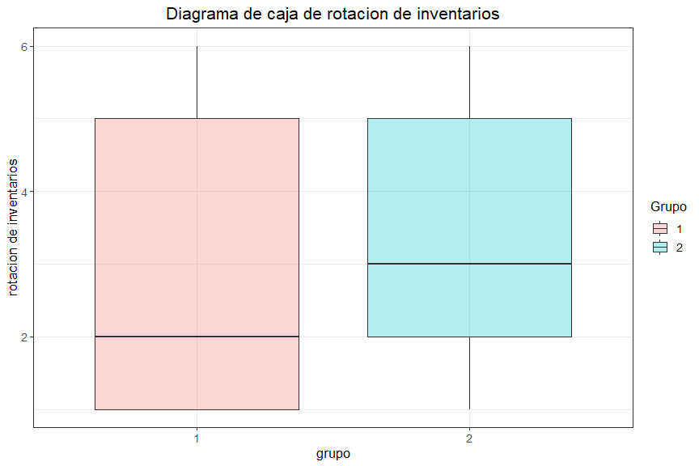

```r
crear_boxplot(datos_segmentados, rotacion_inventarios,
              etiqueta = "rotacion de inventarios")
```

### 2.43. Rotación de cuentas por cobrar

```r
resumir_datos(datos_segmentados, rotacion_cxc, continuo = FALSE, moneda = FALSE)
```

| grupo | Media | Mínimo | Q1 | Mediana | Q3 | Máximo |
| --- | --- | --- | --- | --- | --- | --- |
| 1 | 2.43 | 1 | 1 | 2 | 4 | 4 |
| 2 | 2.40 | 1 | 1 | 2 | 3 | 4 |

La rotación de cuentas por cobrar nos indica que las empresas del grupo 1 tienden a asociarse a los valores más altos, lo cual se aprecia en el cuartil 3 y en el valor de la media, sin embargo se destaca que en las medidas de resumen la diferencia entre ambos grupos no parece ser significativa.

```r
proporciones_categoricas(datos_segmentados, rotacion_cxc)
```

| rotacion_cxc | grupo 1 | grupo 2 |
| --- | --- | --- |
| 1 | 30.8% | 27.94% |
| 2 | 24.72% | 27.73% |
| 3 | 15.19% | 21.12% |
| 4 | 29.28% | 23.21% |

La tabla de proporciones nos aporta un poco de información, donde se observa que las empresas del grupo 1 se concentran en valores extremos (los niveles 1 y 4) principalmente, mientras que las asociadas al grupo 2 se distribuyen entre los todos los niveles, indicando que los clientes poseen rotaciones variadas.

**Click para ver el gráfico de caja**

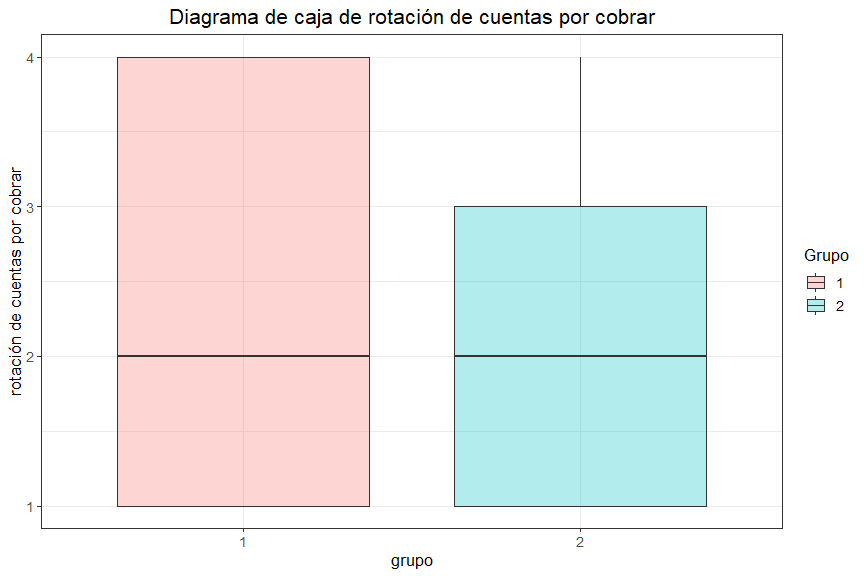

```r
crear_boxplot(datos_segmentados, rotacion_cxc,
              etiqueta = "rotación de cuentas por cobrar")
```

### 2.44. Rotación de cuentas por pagar

```r
resumir_datos(datos_segmentados, rotacion_cxp, continuo = FALSE, moneda = FALSE)
```

| grupo | Media | Mínimo | Q1 | Mediana | Q3 | Máximo |
| --- | --- | --- | --- | --- | --- | --- |
| 1 | 2.16 | 1 | 1 | 2 | 3 | 4 |
| 2 | 2.19 | 1 | 1 | 2 | 3 | 4 |

Los resultados de las medidas de resumen indican que no existe gran diferencia entre la rotación de cuentas por pagar de ambos grupos, donde la mas significativa se evidencia en la media donde el grupo 2 se destaca un poco más, sin embargo, ambos presentan valores sumamente cercanos.

```r
proporciones_categoricas(datos_segmentados, rotacion_cxp)
```

| rotacion_cxp | grupo 1 | grupo 2 |
| --- | --- | --- |
| 1 | 38.67% | 36.37% |
| 2 | 27.49% | 28.41% |
| 3 | 13.26% | 15.05% |
| 4 | 20.58% | 20.18% |

La tabla de proporciones nos permite confirmar lo mencionado en las medidas de resumen, permitiendo verificar que el grupo 1 se destaca en los niveles mas extremos (1 y 4), mientras que el grupo 2 se destaca en los intermedios, sin embargo, se concluye para esta característica que las diferencias entre ambos son muy bajas.

**Click para ver el gráfico de caja**

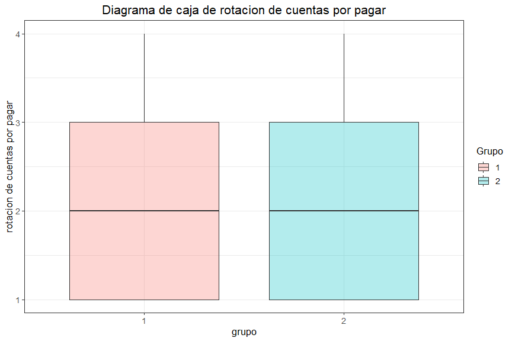

```r
crear_boxplot(datos_segmentados, rotacion_cxp,
              etiqueta = "rotacion de cuentas por pagar")
```

### 2.45. Ciclo de negocios

```r
resumir_datos(datos_segmentados, ciclo_negocio, continuo = FALSE, moneda = FALSE)
```

| grupo | Media | Mínimo | Q1 | Mediana | Q3 | Máximo |
| --- | --- | --- | --- | --- | --- | --- |
| 1 | 4.09 | 1 | 3 | 4 | 6 | 6 |
| 2 | 4.14 | 1 | 3 | 4 | 5 | 6 |

Similar a lo evidenciado con las medidas de rotación, no se aprecian diferencias muy significativas para ambos grupos en cuanto al ciclo de negocio, donde se destaca levemente el grupo 1 a partir del cuartil 3 y el grupo 2 en el valor de la media.

```r
proporciones_categoricas(datos_segmentados, ciclo_negocio)
```

| ciclo_negocio | grupo 1 | grupo 2 |
| --- | --- | --- |
| 1 | 9.25% | 5.53% |
| 2 | 14.09% | 11.13% |
| 3 | 11.88% | 13.63% |
| 4 | 18.23% | 25.37% |
| 5 | 16.3% | 21.79% |
| 6 | 30.25% | 22.54% |

Las tabla de proporciones nos muestra una escenario adicional a las medidas de resumen donde el grupo 2 presenta valores mas altos en los niveles intermedios/altos, indicando que las empresas asociadas a este tienden a tener una duración de ciclo media/larga, el grupo 1 por su parte muestra una rotación variada, con una concentración importante en el ciclo más largo.

**Click para ver el gráfico de caja**

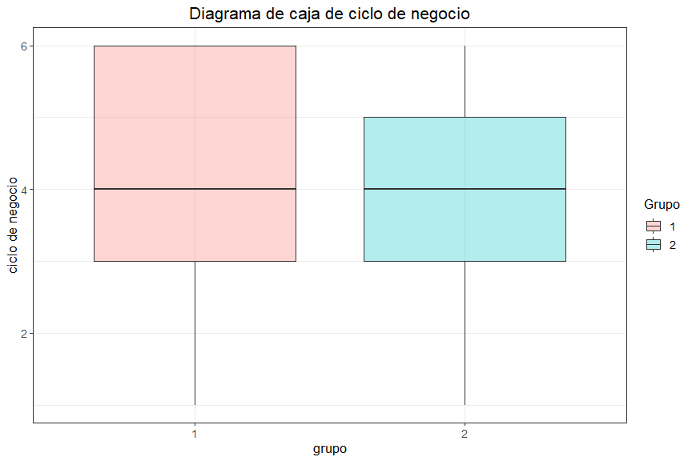

```r
crear_boxplot(datos_segmentados, ciclo_negocio,
              etiqueta = "ciclo de negocio")
```

### 2.46. Ciclo financiero

```r
resumir_datos(datos_segmentados, ciclo_financiero, continuo = FALSE, moneda = FALSE)
```

| grupo | Media | Mínimo | Q1 | Mediana | Q3 | Máximo |
| --- | --- | --- | --- | --- | --- | --- |
| 1 | 3.85 | 1 | 2 | 4 | 6 | 6 |
| 2 | 3.95 | 1 | 3 | 4 | 5 | 6 |

Las medidas de resumen para el ciclo financiero nos muestran un escenario muy similar a lo evidenciado para el ciclo de negocio, donde no se aprecian diferencias muy significativas para ambos grupos, sin embargo, se resalta que grupo 1 presenta valores mas altos a partir del cuartil 3 y el grupo 2 tiene una media levemente mayor.

```r
proporciones_categoricas(datos_segmentados, ciclo_financiero)
```

| ciclo_financiero | grupo 1 | grupo 2 |
| --- | --- | --- |
| 1 | 15.88% | 10.05% |
| 2 | 14.78% | 13.9% |
| 3 | 14.5% | 16.26% |
| 4 | 8.7% | 14.51% |
| 5 | 15.47% | 21.32% |
| 6 | 30.66% | 23.95% |

La tabla de proporciones nos muestra un escenario un poco diferente al ciclo de negocios, donde el grupo 1 presenta una concentración importante en los tres primeros niveles, indicando la presencia de ciclos cortos-medios y con un porcentaje alto en el ciclo más largo. Por su parte el grupo 2 muestra porcentajes importantes de ciclos financieros medios-largos.

**Click para ver el gráfico de caja**

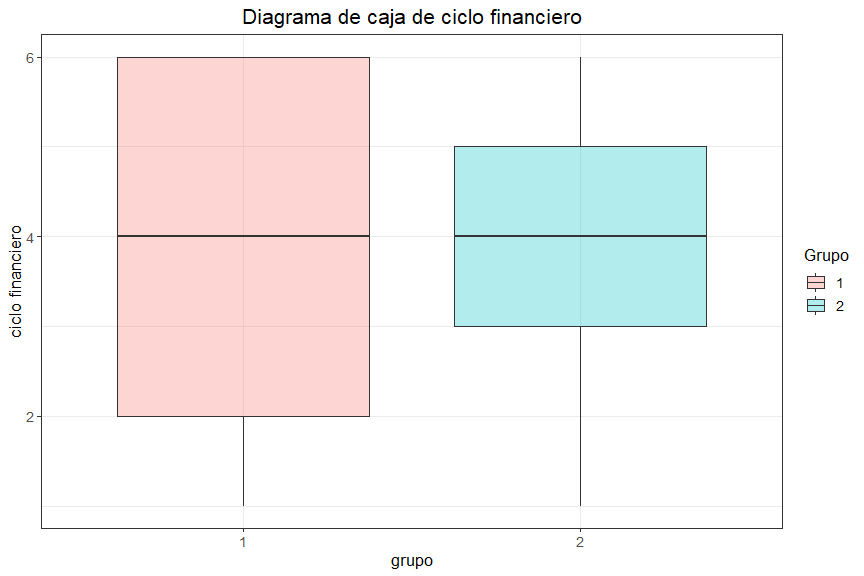

```r
crear_boxplot(datos_segmentados, ciclo_financiero,
              etiqueta = "ciclo financiero")
```

# Referencias

1. Anand, D. (2021). Gower’s Distance. Retrieved 5 July 2021, from https://medium.com/analytics-vidhya/gowers-distance-899f9c4bd553
2. Maechler, M. (2021). pam function - RDocumentation. Retrieved 29 July 2021, from https://www.rdocumentation.org/packages/cluster/versions/2.1.2/topics/pam
3. Kassambara, A. (2021). K-Medoids in R: Algorithm and Practical Examples - Datanovia. Retrieved 5 July 2021, from https://www.datanovia.com/en/lessons/k-medoids-in-r-algorithm-and-practical-examples/
4. Kumar, S. (2021). Silhouette Method — Better than Elbow Method to find Optimal Clusters. Retrieved 5 July 2021, from https://towardsdatascience.com/silhouette-method-better-than-elbow-method-to-find-optimal-clusters-378d62ff6891